# CORALIS-vignette

### 5.1.1 miRNA-target enrichment analysis

Before executing the target enrichment analysis it is recommended to check whether the input is in valid format. *tienrich()* uses as input a vector of IDs in which every item must be a string of characters. Let’s apply some checks:

```r
# check mirs class
class(mirs)
```

```
#> [1] "character"
```

```r
# check mirs format
is.vector(mirs)
```

```
#> [1] TRUE
```

Once the IDs have been checked, we are ready to carry out miRNA-target enrichment analysis on our set of human’s miRNAs. The arguments used for the enriched target genes identification in this examples will be an adjusted p-value (FDR) <0.05 and at least 2 interactions with the miRNAs in the input.

```r
# miRNA-target enrichment analysis with tienrich()
genetar <- tienrich(
                    input_list = mirs,
                    type = "miRNA_mRNA",
                    organism = "Homo sapiens",
                    min = 2,
                    fdr = 0.05
                    )
```

```
#>
#> Analyzing  target genes with >=2 hits for'miRNA'in the input.
#>
#> Analysis complete
```

```r
# Exploring tienrich output.
class(genetar)
```

```
#> [1] "CoralisResult"
#> attr(,"package")
#> [1] "CORALIS"
```

```r
genetar@results %>% head()
```

```
#>   Gene_symbol num_interactions                                        ncRNAs
#> 1    CDC42BPA                2                hsa-miR-98-5p / hsa-miR-485-5p
#> 2   HIST1H2AG                3 hsa-miR-98-5p / hsa-miR-1291 / hsa-miR-485-5p
#> 3    HIST1H4H                2                  hsa-miR-98-5p / hsa-miR-1291
#> 4     IGF2BP2                2                hsa-miR-98-5p / hsa-miR-589-3p
#> 5      MED13L                2                hsa-miR-98-5p / hsa-miR-582-3p
#> 6       ABCC1                2                  hsa-miR-98-5p / hsa-miR-1291
#>         pvalue       FDR        OR     OR.SE OR.IC.lower OR.IC.upper
#> 1 0.0010937503 0.0356036  56.63736 0.8486273   10.733718   298.85180
#> 2 0.0011266963 0.0356036  20.38710 0.7186965    4.984250    83.38941
#> 3 0.0010937503 0.0356036  56.63736 0.8486273   10.733718   298.85180
#> 4 0.0003790712 0.0356036 105.42857 0.8866236   18.546541   599.31302
#> 5 0.0005770561 0.0356036  81.93651 0.8685365   14.934057   449.54905
#> 6 0.0033190250 0.0356901  30.54762 0.8275950    6.032915   154.67764
```

```r
genetar@not_found
```

```
#> [1] "Empty"
```

“*genetar*” stores the result of the miRNA-target enrichment analysis. First of all, *tienrich()* output is an object belonging to the **CoralisResult** class. This object contains 2 slots. * 1) The first one, @results, is the result of the miRNA-target enrichment analysis in which we have several information: i) the target gene in Official Gene Symbol format(Gene_symbol); ii) the number of interactions between the target gene and the ncRNAs in the input (num_int); iii) the ID of the ncRNAs involved in the interaction (ncRNAs); iv) the p-value (pvalue); v) the adjusted p-value (FDR); vi) the odds ratio (OR); vii) the standard-error of the OR (OR.SE); viii) the relative confidence intervals of the OR (OR.IC).

- 2. The second slot, @notfound, stores the ncRNA IDs in the input list for which no experimentally validated target genes have been found.

### 5.1.2 Visualization of enriched targets

CORALIS also allows to visually analyze the output of the target enrichment analysis. Specifically, the *nodeVisu()* function provides a series of graphs to explore the interaction between the ncRNAs of interest and their target genes, as well as different statistical parameters obtained in the enrichment analyses.

Firstly, you can use the ncRNA-target enrichment output directly as input of *nodeVisu()*, but it also supports the slot @results independently. The user can choose the number of *top* target genes to be represented in the graphs.

With the *type* argument the graphic format is specified.

- 1. If *type* = “barplot” it creates a barplot for visualizing the number of interactions that top target genes have with the ncRNAs in the input.

We will now visually explore the result of the miRNA-target enrichment analysis for the top 30 target genes. The following bar chart represents on the y-axis the name of the target genes, and on the x-axis the number of interactions that each of these genes has with the ncRNAs in the input. The gradient indicates the FDR of the enrichment analysis.

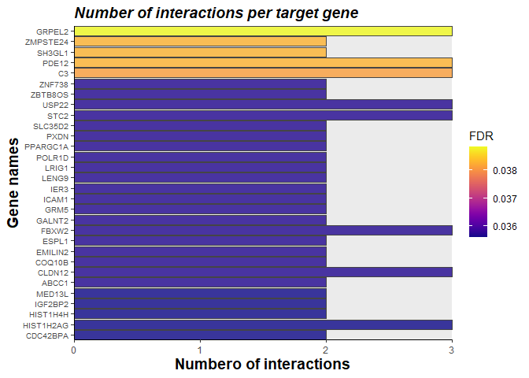

```r
# Barplot of targets genes
bar <- nodeVisu(obj = genetar,top = 30, type = "barplot")
print(bar)
```

- 2. If *type* = “network”, then it creates at html widget to analyze interactively the network of interactions between the ncRNAs and their top target genes according to the enrichment analysis.

This graphical representation provides a more detailed information on the interaction between ncRNAs and the top target genes selected. The nodes color of the 3D network graph represent all significant ncRNAs (miRNAs in this example) and their target genes in orange and purple, respectively. The radius size of the node indicates the number of interactions for one specific gene, that is, the larger the number of interactions between the enriched target gene and the ncRNAs in the input the larger will be the size of the node. On the other hand, the links/edges thickness reports the FDR of the interactions (the thicker the link, the lower the FDR, and therefore, the signification of the interaction is higher).

```r
# Interactive 3D network
net <- nodeVisu(obj = genetar,
                top = 30,
                fixedsize = FALSE, # if true, default node size is fixed
                type = "network")
net
```

[interactive chart not shown]

### 5.1.3 Functional enrichment analysis

Once we have found the enriched target genes whose expression may be altered by the differentially expressed miRNAs, the next step is to identify the biological processes in which the enriched genes are involved, and could therefore be altered after the treatment.

There are available packages in Bioconductor that allow for functional enrichment analysis. Here we use the *enrichGO* function (*clusterProfiler* package [3]) to identify whether the top 25 gene targets are overrepresented in any biological process listed in the Gene Ontology database (see [Gene Ontholgy resources](http://geneontology.org/))[4].

```r
# Load dependencies for pathway enrichment analysis
if (!require("BiocManager", quietly = TRUE))
  install.packages("BiocManager")

#if (!require("biomaRt", quietly = TRUE))
#  BiocManager::install("biomaRt")
library(biomaRt)

#if (!require("clusterProfiler", quietly = TRUE))
#  BiocManager::install("clusterProfiler")
library(clusterProfiler)

#if (!require("org.Hs.eg.db", quietly = TRUE))
#  BiocManager::install("org.Hs.eg.db")
library(org.Hs.eg.db)

# 1- convert gene target's symbol into ENTREZID format
gene <- genetar@results$Gene_symbol[1:25] # top 25 targets

# Use Homo sapiens dataset
ensembl <-useDataset("hsapiens_gene_ensembl",
                     mart = useEnsembl("ensembl","oaries_gene_ensembl"))

# Get the gene IDs
gene_id <- unique(getBM(attributes = c("hgnc_symbol", "entrezgene_id"),
                        filters = "hgnc_symbol",
                        values = gene,
                        mart = ensembl))

# 2- Functional enrichment analysis (GO terms)
biopro <- enrichGO(gene          = gene_id$entrezgene_id,
                   keyType       = "ENTREZID",
                   OrgDb         = org.Hs.eg.db,
                   ont           = "BP",
                   pAdjustMethod = "fdr",
                   pvalueCutoff  = 0.05,
                   qvalueCutoff  = 0.05)

# Let's filter GO temrs which FDR (p.adjust) < 0.05
s_biopro <- subset(biopro@result, p.adjust < 0.05)
head(s_biopro, n = 10)
```

```
#>                    ID                       Description GeneRatio  BgRatio
#> GO:1904646 GO:1904646 cellular response to amyloid-beta      3/22 45/18800
#> GO:1904645 GO:1904645          response to amyloid-beta      3/22 55/18800
#>                  pvalue  p.adjust      qvalue         geneID Count
#> GO:1904646 1.911698e-05 0.0099444 0.008178537 4363/2915/3383     3
#> GO:1904645 3.507725e-05 0.0099444 0.008178537 4363/2915/3383     3
```

```r
# Filter the miRNA target enrichment matrix to identify the miRNAs involved in the deregulation of genes in GO:1904646
genes_go1904646_entrezid <- subset(s_biopro, ID == "GO:1904646") %>%
                            dplyr::select(., geneID) %>%
                            str_split(., "/", simplify = FALSE) %>%
                            unlist(.)

genes_go1904646_symbol <- subset(gene_id, entrezgene_id %in% genes_go1904646_entrezid) %>%
                          dplyr::select(., hgnc_symbol) %>%
                          pull(.)

# Fin the miRNAs involved in the regulation of genes in GO:1904646
mirnas_go1904646<- subset(genetar@results, Gene_symbol %in% genes_go1904646_symbol)
mirnas_go1904646
```

```
#>    Gene_symbol num_interactions                            ncRNAs      pvalue
#> 6        ABCC1                2      hsa-miR-98-5p / hsa-miR-1291 0.003319025
#> 13        GRM5                2 hsa-miR-582-3p / hsa-miR-548ae-5p 0.004706178
#> 14       ICAM1                2    hsa-miR-98-5p / hsa-miR-485-5p 0.005647168
#>          FDR       OR     OR.SE OR.IC.lower OR.IC.upper
#> 6  0.0356901 30.54762 0.8275950    6.032915    154.6776
#> 13 0.0356901 25.23153 0.8232438    5.025707    126.6747
#> 14 0.0356901 22.83929 0.8212783    4.566770    114.2236
```

We can now individually analyze whether the significant enriched target genes from the input list are significantly involved in a specific GO term, such as the GO:1904646. This information can be depicted in network of interactions where the genes within a specific GO term and their related miRNAs are represented.

```r
# Plot 3D network of interactions between genes in GO:1904646 and the deregulated miRNAs.
net_go1904646<- nodeVisu(obj = mirnas_go1904646,
                         type= "network")
net_go1904646
```

[interactive chart not shown]

# 6. CONCLUSION

In conclusion, CORALIS helps to analyze the complex regulatory network between ncRNAs and their target genes. In this example we have carried out miRNA-target enrichment analysis in humans, but CORALIS supports other ncRNA-target enrichment analysis such lncRNAs, snRNAs or snoRNAs, as well as different species. Furthermore, CORALIS’s functionalities are enhanced when it is used in conjunction with other packages that allows functional analysis derived from the regulation of ncRNAs on their target genes. In further versions, CORALIS will include a wider range of ncRNAs, species, graphs and additional databases for interaction networks.

# 8. REFFERENCES

1. Romano G, Veneziano D, Acunzo M, Croce CM. Small non-coding RNA and cancer. Carcinogenesis. 2017 May 1;38(5):485-491. doi: 10.1093/carcin/bgx026. PMID: 28449079; PMCID: PMC6248440.
2. Benjamini, Y., and Hochberg, Y. (1995). Controlling the false discovery rate: a practical and powerful approach to multiple testing. Journal of the Royal Statistical Society Series B, 57, 289–300. http://www.jstor.org/stable/2346101.
3. Yu G, Wang L, Han Y, He Q (2012). “clusterProfiler: an R package for comparing biological themes among gene clusters.” OMICS: A Journal of Integrative Biology, 16(5), 284-287. doi: 10.1089/omi.2011.0118.
4. The Gene Ontology resource: enriching a GOld mine. Nucleic Acids Res. Jan 2021;49(D1):D325-D334.